# Projet Mixture model : MFEAT1

#Binome: - Wacim BELAHCEL - Imad Oualid KACIMI

```r
library(R.matlab)
library(Factoshiny)
library(NbClust)
library(Rmixmod)
library(mclust)
library(clusterSim)
library(aricode)
library(h2o)
library(Rtsne)
library(tidyverse)
```

# Q1 : Introduction table de donnée

MFEAT1 (Multiple Features Data Set) est un sous ensemble du dataset original contenant plus de variable, ce dataset contient 10 classes, chaque individu représente un chiffre écris à la main, et chaque variable represente un pixel.

```r
MFEAT1 = readMat(con="C:\\Users\\GIGABYTE\\Downloads\\DATA_MATLAB - Projet-master-MLDS\\DATA_MATLAB - Projet-master-MLDS\\MFEAT1.mat")
```

```r
y_data = as.data.frame(MFEAT1$y)
x_data = as.data.frame(MFEAT1$X)
#x_test_data = as.data.frame(mnist$testX)
#y_test_data = as.data.frame(mnist$testY)
```

```r
x_data$y<-as.factor(t(y_data))

x_data <- x_data[!duplicated(x_data[,1:240]), ]
y_data <- as.data.frame(x_data$y)
```

# Question 2: ACP

Depuis le graph des individus, on remarque que les classes sont trés mélangé et qu’il est difficile de les séparé, cependant certaines classes restent plus ou moins séparable, on remarque par exemple la classe y1 qui semble contribuer fortement à l’axe 2 et se démarquer des autres classes sur cet axe, on remarque aussi la classe y_8 qui semble se démarquer et contribuer fortement à la création de l’axe 1, pour finir les classes y_5 et y_7 bien qu’il y’a un certain chevauchements entre les deux restent plus ou moin distinguable et sont assez séparé du reste.

Lorsque l’on représente uniquement les modalité de la variable cible y, on peut confirmer notre précedente observations.

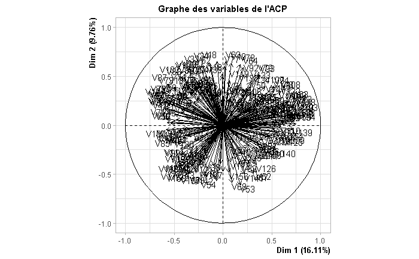

```r
res.PCA<-PCA(x_data,quali.sup=c(241),graph=FALSE)
plot.PCA(res.PCA,choix='var',title="Graphe des variables de l'ACP")
```

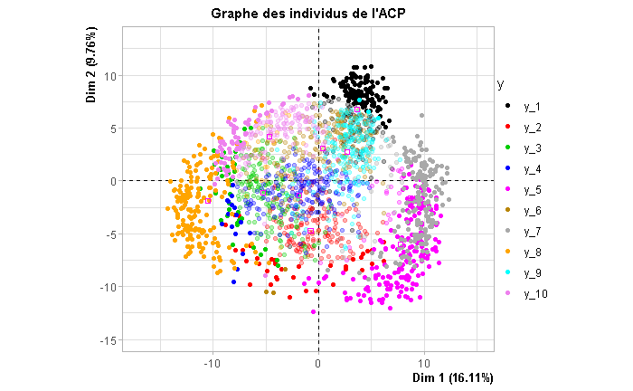

```r
plot.PCA(res.PCA,invisible=c('ind.sup'),select='contrib  804',habillage=241,title="Graphe des individus de l'ACP",label ='none')
```

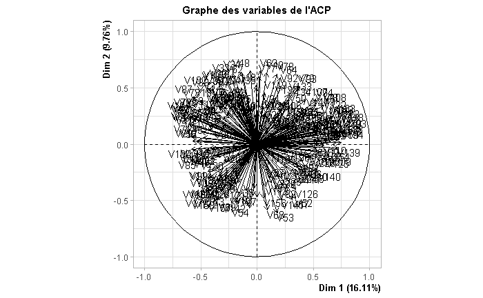

```r
res.PCA<-PCA(x_data,quali.sup=c(241),graph=FALSE)
plot.PCA(res.PCA,choix='var',title="Graphe des variables de l'ACP")
```

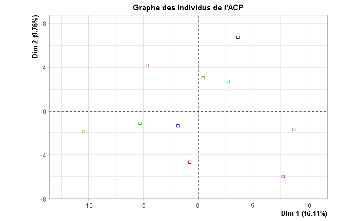

```r
plot.PCA(res.PCA,invisible=c('ind','ind.sup'),select='contrib  804',habillage=241,title="Graphe des individus de l'ACP",label =c('quali'))
```

# Q4: Clustering Kmean / CAH

La plus part des algorithme ne trouvent que 2 classes en tant que nombre optimal lorsque nous appliquons un clustering à l’exception de average ui en trouve 4 et le lien maximum qui en trouve 3, en se basant sur la majorité on pourrait proposer 2 classes, ce qui est tres loin du nombre de classes original.

```r
res_cah_ward <-NbClust(x_data[,1:240], distance = "euclidean", min.nc=2, max.nc=10, method = "ward.D2",
index = "ch")
res_cah_average<-NbClust(x_data[,1:240], distance = "euclidean", min.nc=2, max.nc=10, method = "average",
index = "ch")
res_cah_complete <-NbClust(x_data[,1:240], distance = "euclidean", min.nc=2, max.nc=10, method = "complete",
index = "ch")
res_cah_single <-NbClust(x_data[,1:240], distance = "euclidean", min.nc=2, max.nc=10, method = "single",
index = "ch")
res_cah_kmeans <-NbClust(x_data[,1:240], distance = "euclidean", min.nc=2, max.nc=10, method = "kmeans",
index = "ch")
```

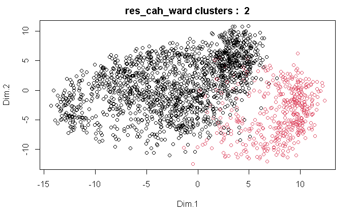

```r
plot(res.PCA$ind$coord,col=res_cah_ward$Best.partition, main = paste("res_cah_ward clusters : ",length(unique(res_cah_ward$Best.partition))))
```

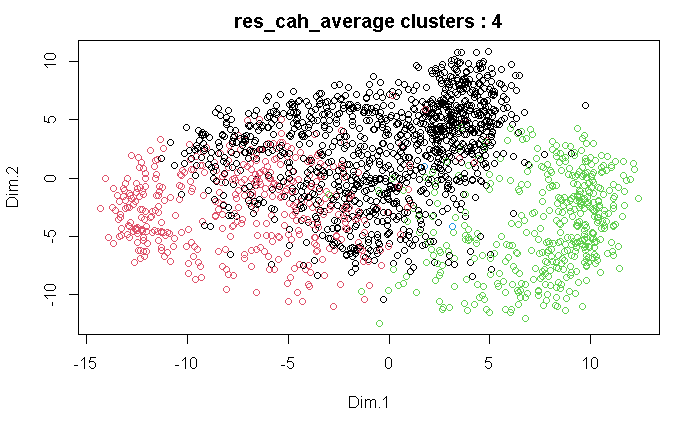

```r
plot(res.PCA$ind$coord,col=res_cah_average$Best.partition, main = paste("res_cah_average clusters :",length(unique(res_cah_average$Best.partition))))
```

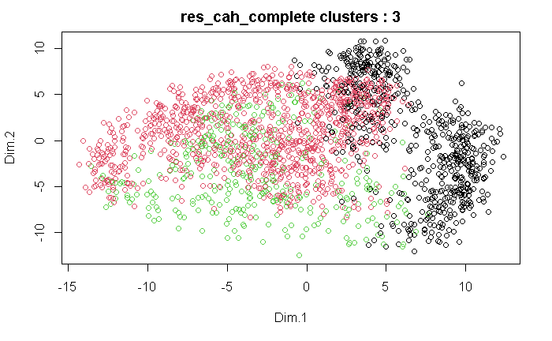

```r
plot(res.PCA$ind$coord,col=res_cah_complete$Best.partition,  main = paste("res_cah_complete clusters :",length(unique(res_cah_complete$Best.partition))))
```

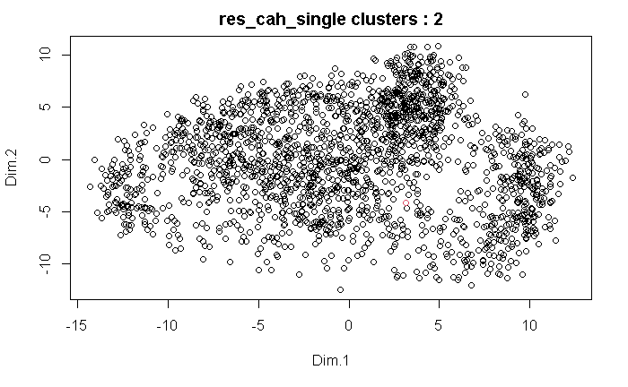

```r
plot(res.PCA$ind$coord,col=res_cah_single$Best.partition, main = paste("res_cah_single clusters :",length(unique(res_cah_single$Best.partition))))
```

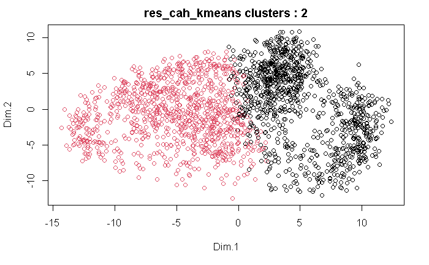

```r
plot(res.PCA$ind$coord,col=res_cah_kmeans$Best.partition, main = paste("res_cah_kmeans clusters :",length(unique(res_cah_kmeans$Best.partition))))
```

# Q5 : HCPC

En observant aussi le graph de l’inertie, on peut confirmer que nous avons un coude au niveau de la 3 éme barre. on peut donc proposer 3 classes.

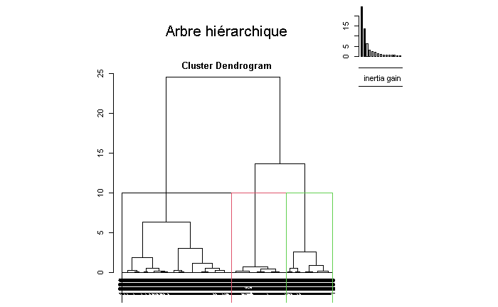

```r
res.PCA<-PCA(x_data,ncp=2,quali.sup=c(241),graph=FALSE)
res.HCPC<-HCPC(res.PCA,nb.clust=3,consol=FALSE,graph=FALSE)
plot.HCPC(res.HCPC,choice='tree',title='Arbre hiérarchique')
```

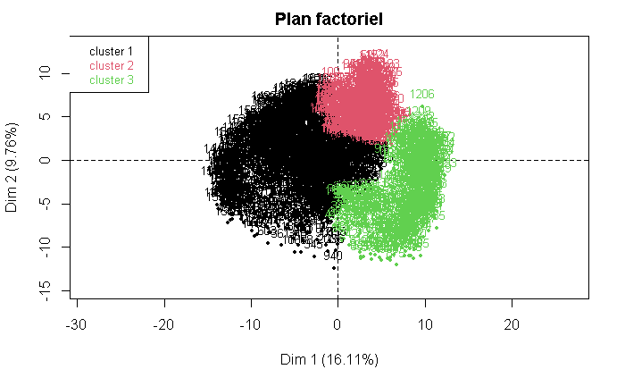

```r
plot.HCPC(res.HCPC,choice='map',draw.tree=FALSE,title='Plan factoriel')
```

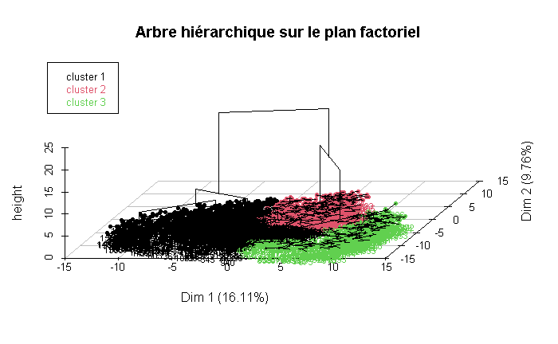

```r
plot.HCPC(res.HCPC,choice='3D.map',ind.names=TRUE,centers.plot=FALSE,angle=60,title='Arbre hiérarchique sur le plan factoriel')
```

# Q6 : comparaison avec HCPC

```r
table(as.vector(res.HCPC$data.clust[,"clust"]),as.vector(res_cah_ward$Best.partition))
```

```
       1    2
  1 1019   18
  2  497   22
  3   41  397
```

```r
table(as.vector(res.HCPC$data.clust[,"clust"]),as.vector(res_cah_kmeans$Best.partition))
```

```
      1   2
  1 109 928
  2 484  35
  3 407  31
```

```r
table(as.vector(res.HCPC$data.clust[,"clust"]),as.vector(res_cah_complete$Best.partition))
```

```
      1   2   3
  1  25 724 288
  2 237 265  17
  3 342  36  60
```

```r
table(as.vector(res.HCPC$data.clust[,"clust"]),as.vector(res_cah_single$Best.partition))
```

```
       1    2
  1 1037    0
  2  519    0
  3  437    1
```

```r
table(as.vector(res.HCPC$data.clust[,"clust"]),as.vector(res_cah_average$Best.partition))
```

```
      1   2   3   4
  1 597 416  23   1
  2 495   8  16   0
  3  41   2 394   1
```

# Q7 : MCLUST et RMIXMOD

```r
set.seed(1)
res.PCA<-PCA(x_data,ncp=15,quali.sup=c(241),graph=FALSE)

res.mclust=Mclust(res.PCA$ind$coord,G = 1:10)
```

```
fitting ...
```

```r
summary(res.mclust$BIC)
```

```
Best BIC values:
            VEV,10        VVV,10        VVV,9
BIC      -132257.5 -132268.52522 -132906.9349
BIC diff       0.0     -11.03658    -649.4462
```

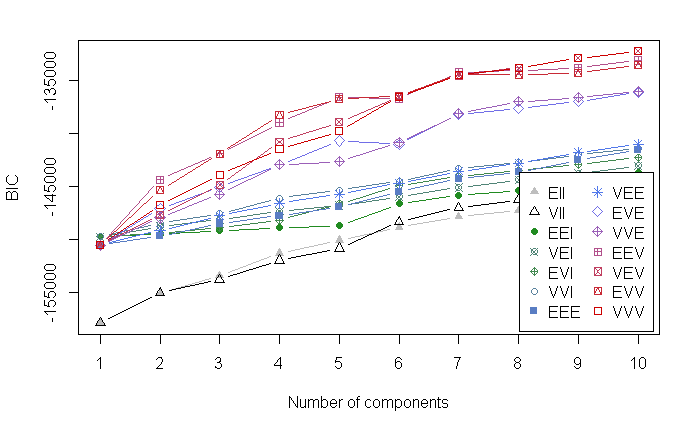

```r
plot(res.mclust,what="BIC")
```

```r
names(res.mclust)
```

```
 [1] "call"           "data"           "modelName"      "n"
 [5] "d"              "G"              "BIC"            "loglik"
 [9] "df"             "bic"            "icl"            "hypvol"
[13] "parameters"     "z"              "classification" "uncertainty"
```

```r
table(res.mclust$class,as.vector(y_data[,1]))
```

```
       1  10   2   3   4   5   6   7   8   9
  1  189   0   0   0   0   0   0   0   0   1
  2    9  34  11   8  16   0 191  27   3  24
  3    1   0   0   0   0   0   0   0   0 169
  4    1   3  16   2   3 178   3   4   0   6
  5    0   1 173   0   1  21   0   0   1   0
  6    0   0   0   1   0   0   0   0 192   0
  7    0   0   0 189   0   0   0   0   0   0
  8    0   0   0   0 179   0   4   0   0   0
  9    0 161   0   0   0   1   1   0   3   0
  10   0   0   0   0   0   0   0 167   0   0
```

```r
res.mclust$modelName
```

```
[1] "VEV"
```

```r
adjustedRandIndex(res.mclust$class,as.vector(y_data[,1]))
```

```
[1] 0.7731779
```

```r
set.seed(1)
res.mixmod = mixmodCluster(data=as.data.frame(res.PCA$ind$coord),nbCluster=1:10,models=mixmodGaussianModel(listModels = c("Gaussian_pk_Lk_Ck", "Gaussian_pk_L_I", "Gaussian_pk_Lk_I", "Gaussian_pk_L_B", "Gaussian_pk_Lk_B", "Gaussian_pk_L_Bk", "Gaussian_pk_Lk_Bk", "Gaussian_pk_L_C", "Gaussian_pk_Lk_C", "Gaussian_pk_L_Dk_A_Dk", "Gaussian_pk_Lk_Dk_A_Dk", "Gaussian_pk_L_Ck", "Gaussian_pk_Lk_Ck", "Gaussian_p_L_I", "Gaussian_p_Lk_I", "Gaussian_p_L_B", "Gaussian_p_Lk_B", "Gaussian_p_L_Bk", "Gaussian_p_Lk_Bk", "Gaussian_p_L_C", "Gaussian_p_Lk_C",  "Gaussian_p_L_Dk_A_Dk", "Gaussian_p_Lk_Dk_A_Dk")))
#
#res.mixmod
summary(res.mixmod)
```

```
* Number of samples    =  1994
* Problem dimension    =  15
*       Number of cluster =  10
*              Model Type =  Gaussian_p_Lk_Dk_A_Dk
*               Criterion =  BIC(131863.7459)
*              Parameters =  list by cluster
*                  Cluster  1 :
                         Proportion =  0.1000
                              Means =  9.2646 -2.1067 -4.1425 1.1870 0.9745 -1.5890 0.4048 -2.3512 0.3150 -0.5548 0.4419 -1.2192 0.7738 -0.0431 -1.2912
                          Variances = |     2.3689     1.4743    -0.9143    -1.8653     0.6162    -1.0355     0.6345     0.2647    -0.7609    -2.0024    -0.1886     0.3943     0.8713    -0.5067    -0.1665 |
                                      |     1.4743    10.1031    -4.4786    -8.0583    -0.8199    -2.2054    -0.4304    -1.7053     1.0217     0.0709     1.0890     1.1580     0.6903     0.6345    -0.0603 |
                                      |    -0.9143    -4.4786     6.6487     7.7427    -0.3292     0.8562     1.7909     0.6503    -1.2191     1.6407    -1.6940    -0.1995     0.6052    -1.2837    -1.7174 |
                                      |    -1.8653    -8.0583     7.7427    12.7122     0.1269     1.7593     1.5278     1.0154    -1.5604     2.1602    -1.2119    -0.8339     0.0144    -1.9918    -1.3055 |
                                      |     0.6162    -0.8199    -0.3292     0.1269     2.5037    -0.8594     0.3812     0.5596     0.8553    -2.1979     0.1575    -0.5693    -0.0212    -1.4272     1.4133 |
                                      |    -1.0355    -2.2054     0.8562     1.7593    -0.8594     2.4462    -0.6177    -0.3165    -0.2810     1.8736     0.4598    -0.4083     0.0096     0.8399    -0.4062 |
                                      |     0.6345    -0.4304     1.7909     1.5278     0.3812    -0.6177     3.3166     0.8203    -0.4271    -0.8560    -1.9347     0.1991     0.8899    -1.3363     0.0194 |
                                      |     0.2647    -1.7053     0.6503     1.0154     0.5596    -0.3165     0.8203     3.1485    -0.1264    -2.2314    -1.4676    -0.9773     0.6139    -0.9845     1.2505 |
                                      |    -0.7609     1.0217    -1.2191    -1.5604     0.8553    -0.2810    -0.4271    -0.1264     3.8548     0.6046     0.8963    -1.0052    -0.8150    -0.3417     1.1145 |
                                      |    -2.0024     0.0709     1.6407     2.1602    -2.1979     1.8736    -0.8560    -2.2314     0.6046     6.4753     1.4566     0.1453    -0.5882     1.8920    -2.1457 |
                                      |    -0.1886     1.0890    -1.6940    -1.2119     0.1575     0.4598    -1.9347    -1.4676     0.8963     1.4566     3.8939    -0.4203    -0.9110     0.1963     0.3272 |
                                      |     0.3943     1.1580    -0.1995    -0.8339    -0.5693    -0.4083     0.1991    -0.9773    -1.0052     0.1453    -0.4203     1.9038    -0.4253     1.1042    -0.7100 |
                                      |     0.8713     0.6903     0.6052     0.0144    -0.0212     0.0096     0.8899     0.6139    -0.8150    -0.5882    -0.9110    -0.4253     2.2287    -0.8257    -0.7538 |
                                      |    -0.5067     0.6345    -1.2837    -1.9918    -1.4272     0.8399    -1.3363    -0.9845    -0.3417     1.8920     0.1963     1.1042    -0.8257     4.1343    -0.7998 |
                                      |    -0.1665    -0.0603    -1.7174    -1.3055     1.4133    -0.4062     0.0194     1.2505     1.1145    -2.1457     0.3272    -0.7100    -0.7538    -0.7998     3.2786 |
*                  Cluster  2 :
                         Proportion =  0.1000
```

[output cut: 161 more lines]

```r
predictions= mixmodPredict(as.data.frame(res.PCA$ind$coord), classificationRule=res.mixmod["bestResult"])
```

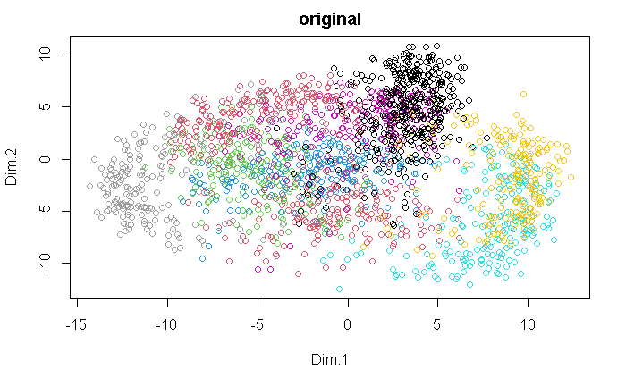

```r
pred.rmix = as.vector(predictions["partition"])
pred.mclust = as.vector(res.mclust$class)
true_values = as.vector(y_data[,1])

plot(res.PCA$ind$coord,col=true_values, main = "original")
```

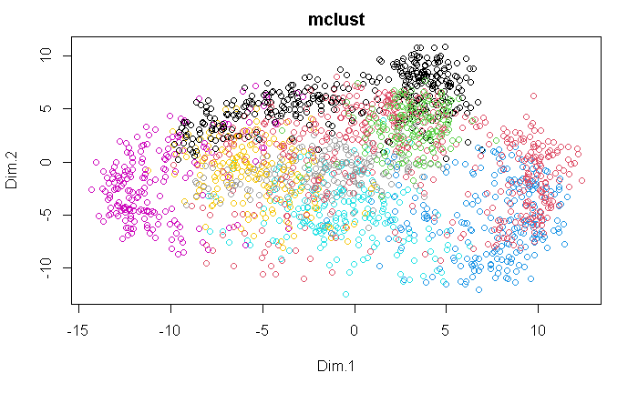

```r
plot(res.PCA$ind$coord,col=pred.mclust, main = "mclust")
```

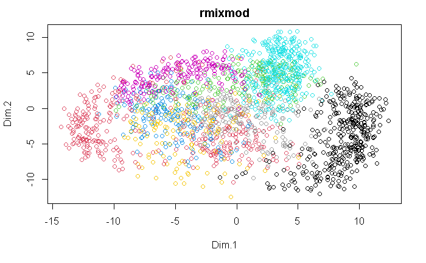

```r
plot(res.PCA$ind$coord,col=pred.rmix, main = "rmixmod")
```

# Q8 : comparer les partitions de mclust et rmixmod

Les resultats des deux packages sont plus ou moins similaire sur la plus part des clusters (exemple cluster 6 de mclust égale au cluster 10 de rmixmod),

```r
table(pred.rmix,pred.mclust)
```

```
         pred.mclust
pred.rmix   1   2   3   4   5   6   7   8   9  10
       1    0   4   0   0   0   0   0   0   0 166
       2    0   2   0   0 167   0   0   0   0   0
       3    0 203   2   0   0   0   0   0   1   1
       4    0   1   0   2   0   0 187   0   0   0
       5  189   9 167   0   0   0   0   0   0   0
       6    0  17   0   0   1   0   0   0 165   0
       7    0  77   0   0  11   0   2  44   0   0
       8    1   9   1  37   1   0   0 139   0   0
       9    0   1   0 177  17   0   0   0   0   0
       10   0   0   0   0   0 193   0   0   0   0
```

# Q9: MclustDR

MclustDR est une methode de reduction de la dimension linéaire utilisé afin de visualiser le resultat de clustering ou de classification obtenue par des mélanges gaussiens.

```r
res.mclustdr = MclustDR(res.mclust)
summary(res.mclustdr)
```

```
-----------------------------------------------------------------
Dimension reduction for model-based clustering and classification
-----------------------------------------------------------------

Mixture model type: Mclust (VEV, 10)

Clusters   n
      1  190
      2  323
      3  170
      4  216
      5  197
      6  193
      7  189
      8  183
      9  166
      10 167

Estimated basis vectors:
             Dir1       Dir2      Dir3      Dir4        Dir5      Dir6      Dir7
Dim.1  -0.1280505  0.0831101 -0.026372  0.023799 -0.09158673  0.538876 -0.055198
Dim.2  -0.2240724 -0.2102986 -0.024439  0.045578 -0.11276249 -0.352341 -0.298021
Dim.3  -0.0929369 -0.1633031  0.131439 -0.089698 -0.22408811  0.160102  0.347974
Dim.4   0.1390153  0.3816537  0.189880 -0.215366 -0.15629580 -0.271651 -0.039569
Dim.5   0.4628007  0.0908626  0.010104  0.096195 -0.34049963  0.175717 -0.339347
Dim.6  -0.0064418  0.3945291 -0.052876  0.494027  0.12869205 -0.231935  0.333998
Dim.7  -0.2374354 -0.0367672  0.192819  0.203124  0.10375964 -0.031997 -0.040977
Dim.8   0.4104741 -0.4768283  0.233421 -0.124425  0.36937035  0.164350 -0.087621
Dim.9  -0.1559088  0.2049504 -0.104435 -0.393688  0.49943109  0.166663 -0.057351
Dim.10  0.2510643 -0.0237373 -0.460178 -0.090491  0.23974773  0.240257 -0.057555
Dim.11  0.1638443 -0.4160917  0.018463  0.155712 -0.21618430  0.029350  0.379851
Dim.12  0.3664388 -0.3768889 -0.177432  0.224561  0.09877376  0.083868  0.313932
Dim.13 -0.2897837 -0.1547657 -0.145055  0.350759 -0.03114447  0.243941 -0.435617
Dim.14 -0.1061295 -0.0467688 -0.702399 -0.435726 -0.51007640 -0.450388  0.331776
Dim.15 -0.3502003  0.0053029  0.286209 -0.286582  0.00051936  0.132605 -0.011782
             Dir8       Dir9      Dir10     Dir11      Dir12     Dir13      Dir14
Dim.1   0.1334676 -0.1792093  0.0049928 -0.017869 -0.0218258  0.014677 -0.0329383
Dim.2   0.0474518 -0.2630332 -0.0042022  0.120396  0.1273983  0.067031 -0.0645635
Dim.3  -0.2504982 -0.0483325 -0.0138301  0.249977  0.0557516 -0.061967 -0.0564802
Dim.4   0.2452082 -0.1373882 -0.1897683  0.265151 -0.1122916 -0.047880  0.0343581
```

[output cut: 19 more lines]

```
Dim.8   0.0811019
Dim.9  -0.1601580
Dim.10 -0.0804708
Dim.11 -0.4143422
Dim.12  0.4927491
Dim.13  0.0641840
Dim.14  0.3673643
Dim.15  0.5696979

               Dir1    Dir2    Dir3    Dir4     Dir5     Dir6     Dir7     Dir8
Eigenvalues  3.5331  1.6486  1.2688  1.1493  0.92515  0.83478  0.76582  0.74489
Cum. %      24.5791 36.0483 44.8753 52.8709 59.30701 65.11439 70.44208 75.62413
                Dir9    Dir10    Dir11    Dir12    Dir13    Dir14     Dir15
Eigenvalues  0.64712  0.60024  0.58121  0.48642  0.47002  0.37045   0.34843
Cum. %      80.12606 84.30183 88.34517 91.72907 94.99891 97.57605 100.00000
```

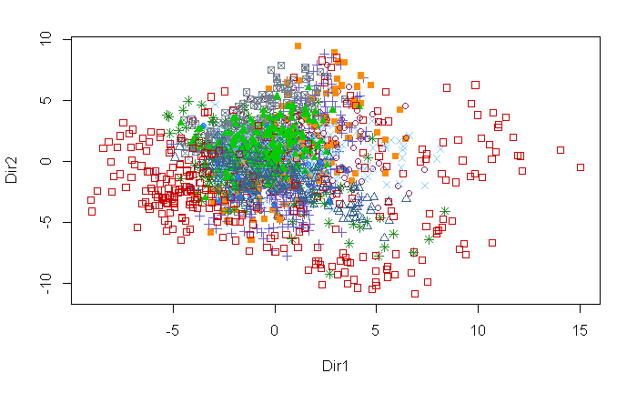

```r
plot(res.mclustdr, what="scatterplot")
```

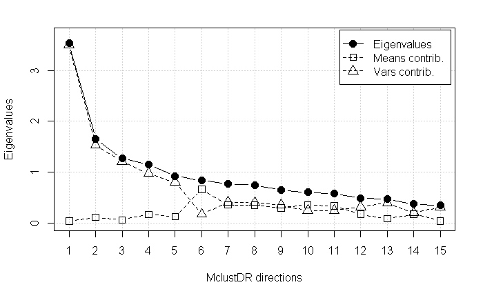

```r
plot(res.mclustdr, what="evalues")
```

# Q10: Comparaison des different algorithmes

D’apres les resultats obtenu, on remarque que le nombre de cluster optimal est bel et bien 10, aussi, mclust semble obtenir les meilleurs resultats sur l’ensemble des methodes, les methodes de melanges en general semble obtenir de bien meilleurs resultats comparé aux algorithmes de clustering standard.

Si nous comparons Mclust à Rmixmod, on voit que mclust semble plus performant. Mclust semble aussi plus rapide, ceci peut étre expliquer par le fait que les deux méthodes utilises de initialisations differente au lancement de leurs algorithmes (cah pour mclust, et un smallEM pour rmixmod), la methode d’initialisation de mclust semble plus rapide et donner de meilleurs resultats en moyenne.

```r
pred.rmix = as.vector(predictions["partition"])
pred.mclust = as.vector(res.mclust$class)
true_values = as.vector(y_data[,1])


print(paste("Rmixmod taux de mal classé : ", 1- comparing.Partitions(pred.rmix,true_values)))
```

```
[1] "Rmixmod taux de mal classé :  0.211005476029839"
```

```r
print(paste("Mclust taux de mal classé : ", 1-comparing.Partitions(pred.mclust,true_values)))
```

```
[1] "Mclust taux de mal classé :  0.146779347897088"
```

```r
print(paste("cah ward taux de mal classé : ", 1-comparing.Partitions(res_cah_ward$Best.partition,true_values)))
```

```
[1] "cah ward taux de mal classé :  0.793285484661922"
```

```r
print(paste("cah average taux de mal classé : ", 1-comparing.Partitions(res_cah_average$Best.partition,true_values)))
```

```
[1] "cah average taux de mal classé :  0.730714623795289"
```

```r
print(paste("cah complete de mal classé : ", 1-comparing.Partitions(res_cah_complete$Best.partition,true_values)))
```

```
[1] "cah complete de mal classé :  0.758684035886758"
```

```r
print(paste("cah singe  taux de mal classé : ", 1-comparing.Partitions(res_cah_single$Best.partition,true_values)))
```

```
[1] "cah singe  taux de mal classé :  0.90788739755812"
```

```r
print(paste("kmeans  taux de mal classé : ", 1-comparing.Partitions(res_cah_kmeans$Best.partition,true_values)))
```

```
[1] "kmeans  taux de mal classé :  0.81678252850436"
```

```r
print("")
```

```
[1] ""
```

```r
print("")
```

```
[1] ""
```

```r
print(paste("Rmixmod ARI : ",adjustedRandIndex(pred.rmix,true_values)))
```

```
[1] "Rmixmod ARI :  0.740438962093399"
```

```r
(paste("Mclust ARI : ",adjustedRandIndex(pred.mclust,true_values)))
```

```
[1] "Mclust ARI :  0.773177859704445"
```

```r
print(paste("cah_ward ARI : ",adjustedRandIndex(res_cah_ward$Best.partition,true_values)))
```

```
[1] "cah_ward ARI :  0.0948913244999086"
```

```r
(paste("cah_average ARI : ",adjustedRandIndex(res_cah_average$Best.partition,true_values)))
```

```
[1] "cah_average ARI :  0.198227727974849"
```

```r
(paste("cah_complete ARI : ",adjustedRandIndex(res_cah_complete$Best.partition,true_values)))
```

```
[1] "cah_complete ARI :  0.157665032867414"
```

```r
(paste("cah_single ARI : ",adjustedRandIndex(res_cah_single$Best.partition,true_values)))
```

```
[1] "cah_single ARI :  -6.68815648033887e-07"
```

```r
(paste("kmeans ARI : ",adjustedRandIndex(res_cah_kmeans$Best.partition,true_values)))
```

```
[1] "kmeans ARI :  0.139139956302493"
```

```r
print("")
```

```
[1] ""
```

```r
print("")
```

```
[1] ""
```

```r
print(paste("Rmixmod NMI : ",NMI(pred.rmix,true_values)))
```

```
[1] "Rmixmod NMI :  0.806090049715704"
```

```r
(paste("Mclust NMI : ",NMI(pred.mclust,true_values)))
```

```
[1] "Mclust NMI :  0.829117954396332"
```

```r
print(paste("cah_ward NMI : ",NMI(res_cah_ward$Best.partition,true_values)))
```

```
[1] "cah_ward NMI :  0.187784763595466"
```

```r
(paste("cah_average NMI : ",NMI(res_cah_average$Best.partition,true_values)))
```

```
[1] "cah_average NMI :  0.296730098359431"
```

```r
(paste("cah_complete NMI : ",NMI(res_cah_complete$Best.partition,true_values)))
```

```
[1] "cah_complete NMI :  0.235650531219759"
```

```r
(paste("cah_single NMI : ",NMI(res_cah_single$Best.partition,true_values)))
```

```
[1] "cah_single NMI :  0.000501342123412692"
```

```r
(paste("kmeans NMI : ",NMI(res_cah_kmeans$Best.partition,true_values)))
```

```
[1] "kmeans NMI :  0.1938090182998"
```

# Q11: TSNE

```r
tsne_res <- Rtsne(x_data[,1:240], dims = 2, perplexity=30, verbose=TRUE, max_iter = 2500)
```

[output not shown]

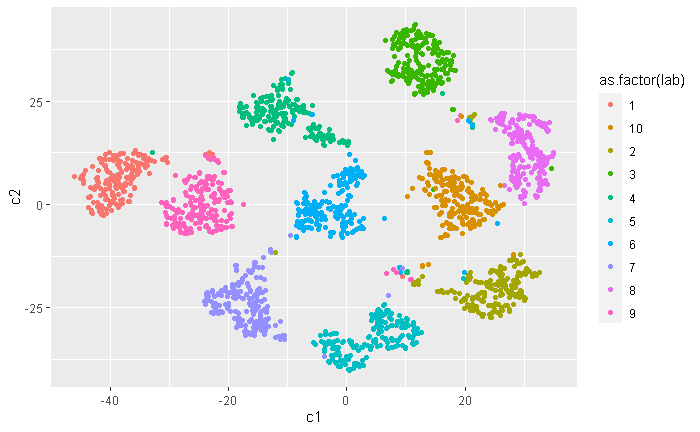

```r
tnse_df = as.data.frame(tsne_res$Y)
tnse_df = cbind(tnse_df,true_values, pred.rmix, pred.mclust)
names(tnse_df) = c("c1", "c2", "lab", "rmix", "mclust")
ggplot(tnse_df, aes(c1, y=c2, color=as.factor(lab)) ) + geom_point()
```

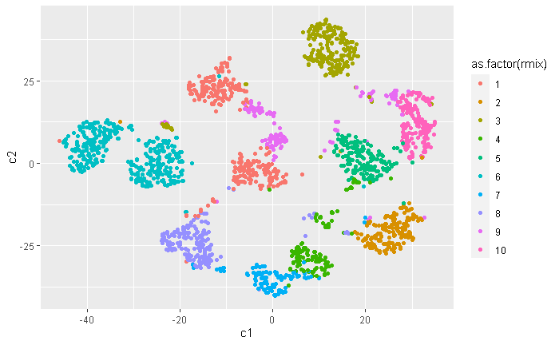

```r
ggplot(tnse_df, aes(c1, y=c2, color=as.factor(rmix)) ) + geom_point()
```

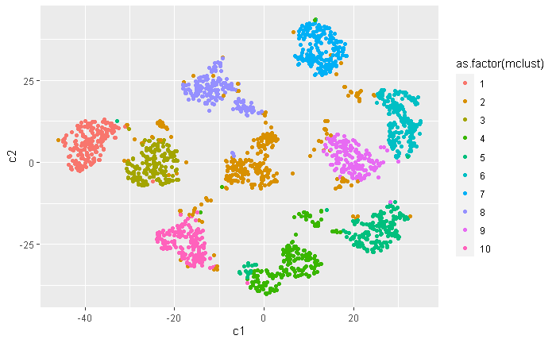

```r
ggplot(tnse_df, aes(c1, y=c2, color=as.factor(mclust))) + geom_point()
```

# Q12 : Reduction par autoencoder

On remarque des resultats legerements superieur pour Rmixmod par rapport à mclust sur l’ensemble des metrics. De maniére plus general la methode de reduction de dimension n’a pas changé grand chose dans ce cas precis, cela peut étre due au paramétrage de notre auto encoder.

```r
h2o.init()
```

[output not shown]

[output not shown]

```r
ae_model <- h2o.deeplearning(x=c(1:240),
                                  model_id="ae_model",
                                  training_frame=as.h2o(x_data[,1:240]),
                                  activation="Tanh",
                                  ignore_const_cols=FALSE,
                                  autoencoder=TRUE,
                                  hidden=c(32,16, 8,16,32),
                                  epochs=75,
                                  reproducible=T,
                                  seed=1)
```

```r
features <- h2o.deepfeatures(ae_model, as.h2o(x_data[,1:240]), layer=3)
```

```r
set.seed(1)
res.mclust=Mclust(features, G = 1:10)
```

```
fitting ...
```

```r
summary(res.mclust$BIC)
```

```
Best BIC values:
            VVV,10     VEV,10      VEV,9
BIC      -8427.539 -8671.8048 -8803.7865
BIC diff     0.000  -244.2662  -376.2479
```

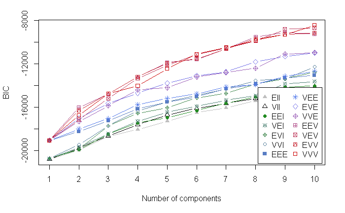

```r
plot(res.mclust,what="BIC")
```

```r
names(res.mclust)
```

```
 [1] "call"           "data"           "modelName"      "n"              "d"              "G"
 [7] "BIC"            "loglik"         "df"             "bic"            "icl"            "hypvol"
[13] "parameters"     "z"              "classification" "uncertainty"
```

```r
table(res.mclust$class,as.vector(y_data[,1]))
```

```
       1  10   2   3   4   5   6   7   8   9
  1  191   0   0   0   0   0   0   1   0   0
  2    0   0   0   0   0   0   0 152   0   0
  3    4   1   0   0   0   0   0  24   0 181
  4    1   4  16   2   5 191   2   2   0   3
  5    4   9  11   3  29   6 196  19   2  15
  6    0   1 169   0   0   3   0   0   0   0
  7    0 183   4   2   3   0   0   0  29   1
  8    0   0   0 193   0   0   0   0   0   0
  9    0   0   0   0 162   0   1   0   0   0
  10   0   1   0   0   0   0   0   0 168   0
```

```r
res.mclust$modelName
```

```
[1] "VVV"
```

```r
adjustedRandIndex(res.mclust$class,as.vector(y_data[,1]))
```

```
[1] 0.7768327
```

```r
res.mixmod = mixmodCluster(data=as.data.frame(features), nbCluster=1:10,models=mixmodGaussianModel(listModels = c("Gaussian_pk_Lk_Ck", "Gaussian_pk_L_I", "Gaussian_pk_Lk_I", "Gaussian_pk_L_B", "Gaussian_pk_Lk_B", "Gaussian_pk_L_Bk", "Gaussian_pk_Lk_Bk", "Gaussian_pk_L_C", "Gaussian_pk_Lk_C", "Gaussian_pk_L_Dk_A_Dk", "Gaussian_pk_Lk_Dk_A_Dk", "Gaussian_pk_L_Ck", "Gaussian_pk_Lk_Ck", "Gaussian_p_L_I", "Gaussian_p_Lk_I", "Gaussian_p_L_B", "Gaussian_p_Lk_B", "Gaussian_p_L_Bk", "Gaussian_p_Lk_Bk", "Gaussian_p_L_C", "Gaussian_p_Lk_C",  "Gaussian_p_L_Dk_A_Dk", "Gaussian_p_Lk_Dk_A_Dk")))
```

```r
predictions= mixmodPredict(as.data.frame(features), classificationRule=res.mixmod["bestResult"])
```

```r
pred.rmix = as.vector(predictions["partition"])
pred.mclust = as.vector(res.mclust$class)
true_values = as.vector(y_data[,1])

print(paste("Rmixmod taux de bien classé : ", comparing.Partitions(pred.rmix,true_values)))
```

```
[1] "Rmixmod taux de bien classé :  0.846336202790751"
```

```r
print(paste("Mclust taux de bien classé : ", comparing.Partitions(pred.mclust,true_values)))
```

```
[1] "Mclust taux de bien classé :  0.838899672122179"
```

```r
print(paste("Rmixmod ARI : ",adjustedRandIndex(pred.rmix,true_values)))
```

```
[1] "Rmixmod ARI :  0.78529576595134"
```

```r
(paste("Mclust ARI : ",adjustedRandIndex(pred.mclust,true_values)))
```

```
[1] "Mclust ARI :  0.776832655431914"
```

```r
print(paste("Rmixmod NMI : ",NMI(pred.rmix,true_values)))
```

```
[1] "Rmixmod NMI :  0.824812314618769"
```

```r
(paste("Mclust NMI : ",NMI(pred.mclust,true_values)))
```

```
[1] "Mclust NMI :  0.823661064798963"
```

[output not shown]